# Chapter 5, Value of Plays Using Run Expectancy

OR 476: Sports Analytics · Lessons 11–13

# Chapter 5. Value of Plays Using Run Expectancy

## 5.1 The Run Expectancy Matrix

The general process for determining the value of a play/action in any sport involves:

1. “Pause” the game. Measure the state of the game and the **expected value of game state pre-action.**
2. “Unpause” the game and collect data on all **actions that take place** (e.g., a pitch, a hit, stolen base)
3. “Pause” the game again. Measure the state of the game and the **expected value of the game state post-action**.
4. **Calculate the change in expected value** from pre-action to post-action. The change in value is attributed to players involved in the action.

In baseball, we use 24 possible base-out states that describe that current state of the game when we “pause” the game.

We can use 4 numbers to describe the baseout state. The first three numbers capture whether each of the 3 bases are occupied or not. The fourth number is the number of outs. For example:

- 0000 implies nobody on, 0 outs
- 1012 implies man on 1st, man on 3rd, 2 outs

**Run expectancy** is the average number of runs a team goes on to score from a given base-out state to the end of the half-inning. The run expectancy is a **value function** over the 24 base-out states. The run expectancy tells us, on average, which states are preferable over others.

## 5.2 Runs Scored in the Remainder of the Inning

We load **2016** play-by-play data from Retrosheet. Note that this method differs from the how the book loads this data - either works.

```r
zip_path <- "data/2016plays.zip"

if (!file.exists(zip_path)) {
  download.file("https://www.retrosheet.org/downloads/plays/2016plays.zip",
                zip_path, mode = "wb")
}

retro2016 <- read_csv(zip_path)
head(retro2016, 3)
```

| gid | event | inning | top_bot | vis_home | site | batteam | pitteam | score_v | score_h | batter | pitcher | lp | bat_f | bathand | pithand | balls | strikes | count | pitches | nump | pa | ab | single | double | triple | hr | sh | sf | hbp | … |
| --- | --- | --- | --- | --- | --- | --- | --- | --- | --- | --- | --- | --- | --- | --- | --- | --- | --- | --- | --- | --- | --- | --- | --- | --- | --- | --- | --- | --- | --- | --- |
| KCA201604030 | 8/L8RD+ | 1 | 0 | 0 | KAN06 | NYN | KCA | 0 | 0 | granc001 | volqe001 | 1 | 9 | L | R | 2 | 2 | 22 | CCBBFX | 6 | 1 | 1 | 0 | 0 | 0 | 0 | 0 | 0 | 0 | … |
| KCA201604030 | 53/G5+ | 1 | 0 | 0 | KAN06 | NYN | KCA | 0 | 0 | wrigd002 | volqe001 | 2 | 5 | R | R | 2 | 2 | 22 | FSBBX | 5 | 1 | 1 | 0 | 0 | 0 | 0 | 0 | 0 | 0 | … |
| KCA201604030 | 63/G6MS- | 1 | 0 | 0 | KAN06 | NYN | KCA | 0 | 0 | cespy001 | volqe001 | 3 | 7 | R | R | 1 | 1 | 11 | BCX | 3 | 1 | 1 | 0 | 0 | 0 | 0 | 0 | 0 | 0 | … |

```r
glimpse(retro2016 |> head(3))
```

```
Rows: 3
Columns: 177
$ gid       <chr> "KCA201604030", "KCA201604030", "KCA201604030"
$ event     <chr> "8/L8RD+", "53/G5+", "63/G6MS-"
$ inning    <dbl> 1, 1, 1
$ top_bot   <dbl> 0, 0, 0
$ vis_home  <dbl> 0, 0, 0
$ site      <chr> "KAN06", "KAN06", "KAN06"
$ batteam   <chr> "NYN", "NYN", "NYN"
$ pitteam   <chr> "KCA", "KCA", "KCA"
$ score_v   <dbl> 0, 0, 0
$ score_h   <dbl> 0, 0, 0
$ batter    <chr> "granc001", "wrigd002", "cespy001"
$ pitcher   <chr> "volqe001", "volqe001", "volqe001"
$ lp        <dbl> 1, 2, 3
```

[output cut: 164 more lines]

We select the columns we need and then compute several new columns

```r
# Keep only regular-season plays and the columns we need, then add:
# runs in the game before the play, a unique id for each half-inning,
# and the runs scored on the play.
pbp <- retro2016
pbp <- pbp |>
  select(gid, inning, top_bot, score_v, score_h, pa,
         single, double, triple, hr, hbp, walk, k,
         outs_pre, outs_post,
         br1_pre, br2_pre, br3_pre,
         br1_post, br2_post, br3_post,
         runs, pn, gametype) |>
  mutate(runs_pre = score_v + score_h,
         half_inning_id = paste(gid, inning, top_bot)) |>
  filter(gametype == "regular")
pbp
```

| gid | inning | top_bot | score_v | score_h | pa | single | double | triple | hr | hbp | walk | k | outs_pre | outs_post | br1_pre | br2_pre | br3_pre | br1_post | br2_post | br3_post | runs | pn | gametype | runs_pre | half_inning_id |
| --- | --- | --- | --- | --- | --- | --- | --- | --- | --- | --- | --- | --- | --- | --- | --- | --- | --- | --- | --- | --- | --- | --- | --- | --- | --- |
| KCA201604030 | 1 | 0 | 0 | 0 | 1 | 0 | 0 | 0 | 0 | 0 | 0 | 0 | 0 | 1 | NA | NA | NA | NA | NA | NA | 0 | 1 | regular | 0 | KCA201604030 1 0 |
| KCA201604030 | 1 | 0 | 0 | 0 | 1 | 0 | 0 | 0 | 0 | 0 | 0 | 0 | 1 | 2 | NA | NA | NA | NA | NA | NA | 0 | 2 | regular | 0 | KCA201604030 1 0 |
| KCA201604030 | 1 | 0 | 0 | 0 | 1 | 0 | 0 | 0 | 0 | 0 | 0 | 0 | 2 | 3 | NA | NA | NA | NA | NA | NA | 0 | 3 | regular | 0 | KCA201604030 1 0 |
| KCA201604030 | 1 | 1 | 0 | 0 | 1 | 0 | 0 | 0 | 0 | 0 | 0 | 0 | 0 | 1 | NA | NA | NA | NA | NA | NA | 0 | 4 | regular | 0 | KCA201604030 1 1 |
| KCA201604030 | 1 | 1 | 0 | 0 | 1 | 0 | 0 | 0 | 0 | 0 | 0 | 0 | 1 | 1 | NA | NA | NA | mousm001 | NA | NA | 0 | 5 | regular | 0 | KCA201604030 1 1 |
| KCA201604030 | 1 | 1 | 0 | 0 | 0 | 0 | 0 | 0 | 0 | 0 | 0 | 0 | 1 | 1 | mousm001 | NA | NA | NA | mousm001 | NA | 0 | 6 | regular | 0 | KCA201604030 1 1 |
| KCA201604030 | 1 | 1 | 0 | 0 | 1 | 0 | 0 | 0 | 0 | 0 | 1 | 0 | 1 | 1 | NA | mousm001 | NA | cainl001 | mousm001 | NA | 0 | 7 | regular | 0 | KCA201604030 1 1 |
| KCA201604030 | 1 | 1 | 0 | 0 | 1 | 1 | 0 | 0 | 0 | 0 | 0 | 0 | 1 | 1 | cainl001 | mousm001 | NA | hosme001 | NA | cainl001 | 1 | 8 | regular | 0 | KCA201604030 1 1 |
| KCA201604030 | 1 | 1 | 0 | 1 | 1 | 0 | 0 | 0 | 0 | 0 | 0 | 0 | 1 | 3 | hosme001 | NA | cainl001 | NA | NA | NA | 0 | 9 | regular | 1 | KCA201604030 1 1 |
| KCA201604030 | 2 | 0 | 0 | 1 | 1 | 0 | 0 | 0 | 0 | 0 | 0 | 1 | 0 | 1 | NA | NA | NA | NA | NA | NA | 0 | 10 | regular | 1 | KCA201604030 2 0 |

[output cut: 9990 more lines]

We use the `half_innings` table to both filter our play-by-play data to complete half innings, and we use it to merge data about the entire half-inning (e.g., runs at the start of the half-inning) which is not available in the play by play data.

```r
# Summarize down to one row per half-inning: the outs recorded (to tell
# complete innings from partial ones), the runs scored during the inning,
# the game score when the inning began, and the game score when it ended.

half_innings <- pbp |>
  group_by(half_inning_id) |>
  summarize(max_outs = max(outs_post),
            runs_final = max(runs_pre + runs))

half_innings
```

| half_inning_id | max_outs | runs_final |
| --- | --- | --- |
| ANA201604040 1 0 | 3 | 1 |
| ANA201604040 1 1 | 3 | 1 |
| ANA201604040 2 0 | 3 | 1 |
| ANA201604040 2 1 | 3 | 1 |
| ANA201604040 3 0 | 3 | 1 |
| ANA201604040 3 1 | 3 | 1 |
| ANA201604040 4 0 | 3 | 3 |
| ANA201604040 4 1 | 3 | 3 |
| ANA201604040 5 0 | 3 | 3 |
| ANA201604040 5 1 | 3 | 3 |

[output cut: 9990 more lines]

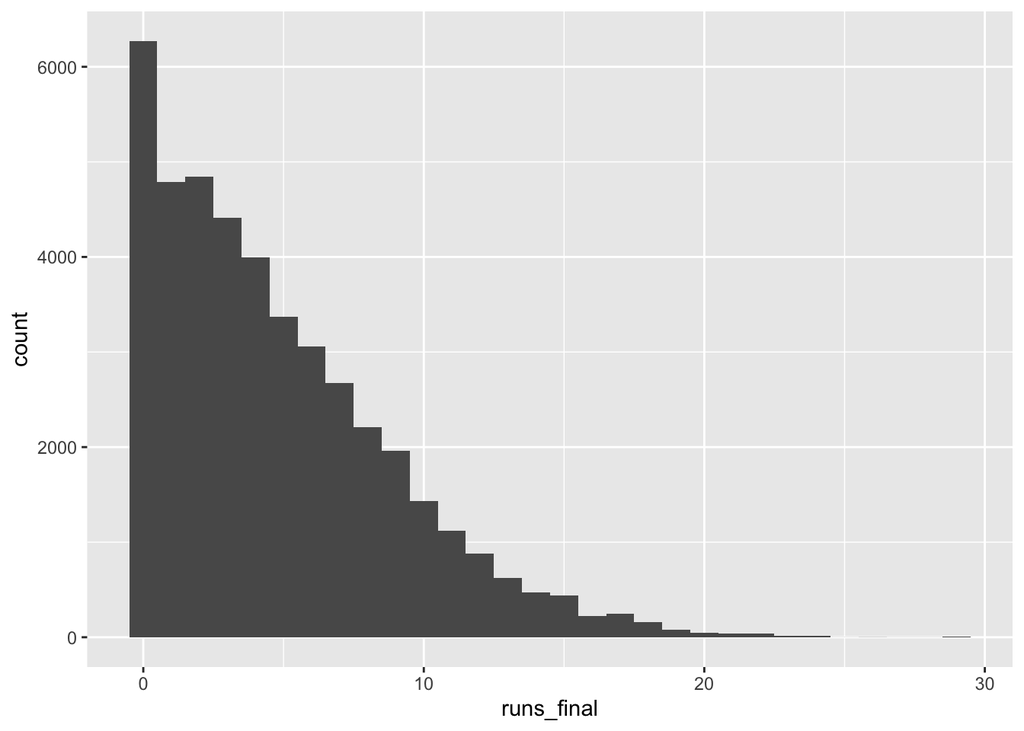

```r
# Sanity-check: how many outs do half-innings end with (most should be 3),
# and how are runs per half-inning distributed?

ggplot(half_innings, aes(x = runs_final)) + geom_histogram()
```

Join the half-inning totals back onto every play, then compute the runs for rest of the half inning.

```r
# Join the half-inning totals back onto every play, then compute the runs
# scored from each play to the end of its half-inning. This is the quantity
# run expectancy averages.

dim(pbp)
```

```
[1] 193695     26
```

```r
pbp <- pbp |> inner_join(half_innings, by = "half_inning_id")

dim(pbp)
```

```
[1] 193695     28
```

```r
pbp
```

| gid | inning | top_bot | score_v | score_h | pa | single | double | triple | hr | hbp | walk | k | outs_pre | outs_post | br1_pre | br2_pre | br3_pre | br1_post | br2_post | br3_post | runs | pn | gametype | runs_pre | half_inning_id | max_outs | runs_final |
| --- | --- | --- | --- | --- | --- | --- | --- | --- | --- | --- | --- | --- | --- | --- | --- | --- | --- | --- | --- | --- | --- | --- | --- | --- | --- | --- | --- |
| KCA201604030 | 1 | 0 | 0 | 0 | 1 | 0 | 0 | 0 | 0 | 0 | 0 | 0 | 0 | 1 | NA | NA | NA | NA | NA | NA | 0 | 1 | regular | 0 | KCA201604030 1 0 | 3 | 0 |
| KCA201604030 | 1 | 0 | 0 | 0 | 1 | 0 | 0 | 0 | 0 | 0 | 0 | 0 | 1 | 2 | NA | NA | NA | NA | NA | NA | 0 | 2 | regular | 0 | KCA201604030 1 0 | 3 | 0 |
| KCA201604030 | 1 | 0 | 0 | 0 | 1 | 0 | 0 | 0 | 0 | 0 | 0 | 0 | 2 | 3 | NA | NA | NA | NA | NA | NA | 0 | 3 | regular | 0 | KCA201604030 1 0 | 3 | 0 |
| KCA201604030 | 1 | 1 | 0 | 0 | 1 | 0 | 0 | 0 | 0 | 0 | 0 | 0 | 0 | 1 | NA | NA | NA | NA | NA | NA | 0 | 4 | regular | 0 | KCA201604030 1 1 | 3 | 1 |
| KCA201604030 | 1 | 1 | 0 | 0 | 1 | 0 | 0 | 0 | 0 | 0 | 0 | 0 | 1 | 1 | NA | NA | NA | mousm001 | NA | NA | 0 | 5 | regular | 0 | KCA201604030 1 1 | 3 | 1 |
| KCA201604030 | 1 | 1 | 0 | 0 | 0 | 0 | 0 | 0 | 0 | 0 | 0 | 0 | 1 | 1 | mousm001 | NA | NA | NA | mousm001 | NA | 0 | 6 | regular | 0 | KCA201604030 1 1 | 3 | 1 |
| KCA201604030 | 1 | 1 | 0 | 0 | 1 | 0 | 0 | 0 | 0 | 0 | 1 | 0 | 1 | 1 | NA | mousm001 | NA | cainl001 | mousm001 | NA | 0 | 7 | regular | 0 | KCA201604030 1 1 | 3 | 1 |
| KCA201604030 | 1 | 1 | 0 | 0 | 1 | 1 | 0 | 0 | 0 | 0 | 0 | 0 | 1 | 1 | cainl001 | mousm001 | NA | hosme001 | NA | cainl001 | 1 | 8 | regular | 0 | KCA201604030 1 1 | 3 | 1 |
| KCA201604030 | 1 | 1 | 0 | 1 | 1 | 0 | 0 | 0 | 0 | 0 | 0 | 0 | 1 | 3 | hosme001 | NA | cainl001 | NA | NA | NA | 0 | 9 | regular | 1 | KCA201604030 1 1 | 3 | 1 |
| KCA201604030 | 2 | 0 | 0 | 1 | 1 | 0 | 0 | 0 | 0 | 0 | 0 | 1 | 0 | 1 | NA | NA | NA | NA | NA | NA | 0 | 10 | regular | 1 | KCA201604030 2 0 | 3 | 1 |

[output cut: 9990 more lines]

## 5.3 Creating the Matrix

Now the other half: label the state each play *starts* in.

Figure out the logic on a small amount of data

```r
# Work out the logic on a few columns first: turn the three runner columns
# and the out count into a single base-out state label like "1012"
# (runners on 1st & 3rd, 2 outs). A base is occupied when its runner column
# is not missing.

pbp <- pbp |>
  mutate(base_out_pre = paste(as.integer(!is.na(br1_pre)),
                              as.integer(!is.na(br2_pre)),
                              as.integer(!is.na(br3_pre)),
                              outs_pre, sep=""))
head(pbp)
```

| gid | inning | top_bot | score_v | score_h | pa | single | double | triple | hr | hbp | walk | k | outs_pre | outs_post | br1_pre | br2_pre | br3_pre | br1_post | br2_post | br3_post | runs | pn | gametype | runs_pre | half_inning_id | max_outs | runs_final | base_out_pre |
| --- | --- | --- | --- | --- | --- | --- | --- | --- | --- | --- | --- | --- | --- | --- | --- | --- | --- | --- | --- | --- | --- | --- | --- | --- | --- | --- | --- | --- |
| KCA201604030 | 1 | 0 | 0 | 0 | 1 | 0 | 0 | 0 | 0 | 0 | 0 | 0 | 0 | 1 | NA | NA | NA | NA | NA | NA | 0 | 1 | regular | 0 | KCA201604030 1 0 | 3 | 0 | 0000 |
| KCA201604030 | 1 | 0 | 0 | 0 | 1 | 0 | 0 | 0 | 0 | 0 | 0 | 0 | 1 | 2 | NA | NA | NA | NA | NA | NA | 0 | 2 | regular | 0 | KCA201604030 1 0 | 3 | 0 | 0001 |
| KCA201604030 | 1 | 0 | 0 | 0 | 1 | 0 | 0 | 0 | 0 | 0 | 0 | 0 | 2 | 3 | NA | NA | NA | NA | NA | NA | 0 | 3 | regular | 0 | KCA201604030 1 0 | 3 | 0 | 0002 |
| KCA201604030 | 1 | 1 | 0 | 0 | 1 | 0 | 0 | 0 | 0 | 0 | 0 | 0 | 0 | 1 | NA | NA | NA | NA | NA | NA | 0 | 4 | regular | 0 | KCA201604030 1 1 | 3 | 1 | 0000 |
| KCA201604030 | 1 | 1 | 0 | 0 | 1 | 0 | 0 | 0 | 0 | 0 | 0 | 0 | 1 | 1 | NA | NA | NA | mousm001 | NA | NA | 0 | 5 | regular | 0 | KCA201604030 1 1 | 3 | 1 | 0001 |
| KCA201604030 | 1 | 1 | 0 | 0 | 0 | 0 | 0 | 0 | 0 | 0 | 0 | 0 | 1 | 1 | mousm001 | NA | NA | NA | mousm001 | NA | 0 | 6 | regular | 0 | KCA201604030 1 1 | 3 | 1 | 1001 |

How many distinct states are there? We expect the 24 real ones — a “3 outs” state never *starts* a play, so it should not appear:

```r
# Count the distinct states to confirm we get the 24 we expect.
pbp |> group_by(base_out_pre) |> summarise(count = n())
```

| base_out_pre | count |
| --- | --- |
| 0000 | 46095 |
| 0001 | 33375 |
| 0002 | 26796 |
| 0010 | 522 |
| 0011 | 1881 |
| 0012 | 2880 |
| 0100 | 3472 |
| 0101 | 5498 |
| 0102 | 7111 |
| 0110 | 687 |

[output cut: 14 more lines]

### The state the play ends in

Same construction from the `*_post` columns, plus `outs_post`:

```r
# Build the base-out state AFTER the play, using the post-play columns.
head(pbp)
```

| gid | inning | top_bot | score_v | score_h | pa | single | double | triple | hr | hbp | walk | k | outs_pre | outs_post | br1_pre | br2_pre | br3_pre | br1_post | br2_post | br3_post | runs | pn | gametype | runs_pre | half_inning_id | max_outs | runs_final | base_out_pre |
| --- | --- | --- | --- | --- | --- | --- | --- | --- | --- | --- | --- | --- | --- | --- | --- | --- | --- | --- | --- | --- | --- | --- | --- | --- | --- | --- | --- | --- |
| KCA201604030 | 1 | 0 | 0 | 0 | 1 | 0 | 0 | 0 | 0 | 0 | 0 | 0 | 0 | 1 | NA | NA | NA | NA | NA | NA | 0 | 1 | regular | 0 | KCA201604030 1 0 | 3 | 0 | 0000 |
| KCA201604030 | 1 | 0 | 0 | 0 | 1 | 0 | 0 | 0 | 0 | 0 | 0 | 0 | 1 | 2 | NA | NA | NA | NA | NA | NA | 0 | 2 | regular | 0 | KCA201604030 1 0 | 3 | 0 | 0001 |
| KCA201604030 | 1 | 0 | 0 | 0 | 1 | 0 | 0 | 0 | 0 | 0 | 0 | 0 | 2 | 3 | NA | NA | NA | NA | NA | NA | 0 | 3 | regular | 0 | KCA201604030 1 0 | 3 | 0 | 0002 |
| KCA201604030 | 1 | 1 | 0 | 0 | 1 | 0 | 0 | 0 | 0 | 0 | 0 | 0 | 0 | 1 | NA | NA | NA | NA | NA | NA | 0 | 4 | regular | 0 | KCA201604030 1 1 | 3 | 1 | 0000 |
| KCA201604030 | 1 | 1 | 0 | 0 | 1 | 0 | 0 | 0 | 0 | 0 | 0 | 0 | 1 | 1 | NA | NA | NA | mousm001 | NA | NA | 0 | 5 | regular | 0 | KCA201604030 1 1 | 3 | 1 | 0001 |
| KCA201604030 | 1 | 1 | 0 | 0 | 0 | 0 | 0 | 0 | 0 | 0 | 0 | 0 | 1 | 1 | mousm001 | NA | NA | NA | mousm001 | NA | 0 | 6 | regular | 0 | KCA201604030 1 1 | 3 | 1 | 1001 |

```r
pbp <- pbp |>
  mutate(base_out_post = paste(as.integer(!is.na(br1_post)),
                              as.integer(!is.na(br2_post)),
                              as.integer(!is.na(br3_post)),
                              outs_post, sep=""))

pbp |> group_by(base_out_post) |> summarise(count = n())
```

| base_out_post | count |
| --- | --- |
| 0000 | 2715 |
| 0001 | 33442 |
| 0002 | 26883 |
| 0003 | 43226 |
| 0010 | 522 |
| 0011 | 1881 |
| 0012 | 2880 |
| 0100 | 3472 |
| 0101 | 5498 |
| 0102 | 7111 |

[output cut: 15 more lines]

### Dropping plays that changed nothing

Some rows leave the base-out state untouched and score no run (a pickoff throw, a foul, a defensive substitution). They should not count as a “transition.” Keep a play only if it **changed the state** or **scored a run**:

```r
# Keep only plays that changed the base-out state or scored a run, and
# check how many rows are left.
dim(pbp)
```

```
[1] 193695     30
```

```r
pbp <- pbp |> filter(base_out_pre != base_out_post | runs > 0)
dim(pbp)
```

```
[1] 190552     30
```

### Averaging over complete innings to get the matrix

Two ingredients are now on the table:

```r
# Make a separate table of complete innings only, to estimate the matrix
# (we keep the full data for run values later).
dim(pbp)
```

```
[1] 190552     30
```

```r
complete_pbp <- pbp |> filter(max_outs > 2)
dim(complete_pbp)
```

```
[1] 189730     30
```

```r
complete_pbp <- complete_pbp |> mutate(runs_roi = runs_final - runs_pre)
```

```r
# The run expectancy matrix: the average runs-to-end-of-inning within each
# starting state. Keep a count of plays per state too.
RE24 <- complete_pbp |>
  group_by(base_out_pre) |>
  summarize(expected_runs = mean(runs_roi)) |>
  arrange(expected_runs)
view(RE24)
```

```r
# Reshape the matrix into a readable grid: bases down the rows, outs across
# the columns.
```

Read it together:

> **MDP callout:** you just estimated $V(s)$ for all 24 states by Monte-Carlo averaging over real trajectories — no Bellman solve, no discounting (the inning is finite and undiscounted). The “policy” is whatever the 2016 league actually did.

## 5.4 Measuring Success of a Batting Play

Now use the formula from the top of the file. Attach $RE(\text{before})$ and $RE(\text{after})$ to every play, then apply $\;RE_{\text{after}} - RE_{\text{before}} + \text{runs}$.

### Join the matrix onto the plays — twice

First for the starting state:

```r
# Attach the run expectancy of the state BEFORE the play to every play.
complete_pbp <- complete_pbp |> inner_join(RE24, by = "base_out_pre")
complete_pbp
```

| gid | inning | top_bot | score_v | score_h | pa | single | double | triple | hr | hbp | walk | k | outs_pre | outs_post | br1_pre | br2_pre | br3_pre | br1_post | br2_post | br3_post | runs | pn | gametype | runs_pre | half_inning_id | max_outs | runs_final | base_out_pre | base_out_post | … |
| --- | --- | --- | --- | --- | --- | --- | --- | --- | --- | --- | --- | --- | --- | --- | --- | --- | --- | --- | --- | --- | --- | --- | --- | --- | --- | --- | --- | --- | --- | --- |
| KCA201604030 | 1 | 0 | 0 | 0 | 1 | 0 | 0 | 0 | 0 | 0 | 0 | 0 | 0 | 1 | NA | NA | NA | NA | NA | NA | 0 | 1 | regular | 0 | KCA201604030 1 0 | 3 | 0 | 0000 | 0001 | … |
| KCA201604030 | 1 | 0 | 0 | 0 | 1 | 0 | 0 | 0 | 0 | 0 | 0 | 0 | 1 | 2 | NA | NA | NA | NA | NA | NA | 0 | 2 | regular | 0 | KCA201604030 1 0 | 3 | 0 | 0001 | 0002 | … |
| KCA201604030 | 1 | 0 | 0 | 0 | 1 | 0 | 0 | 0 | 0 | 0 | 0 | 0 | 2 | 3 | NA | NA | NA | NA | NA | NA | 0 | 3 | regular | 0 | KCA201604030 1 0 | 3 | 0 | 0002 | 0003 | … |
| KCA201604030 | 1 | 1 | 0 | 0 | 1 | 0 | 0 | 0 | 0 | 0 | 0 | 0 | 0 | 1 | NA | NA | NA | NA | NA | NA | 0 | 4 | regular | 0 | KCA201604030 1 1 | 3 | 1 | 0000 | 0001 | … |
| KCA201604030 | 1 | 1 | 0 | 0 | 1 | 0 | 0 | 0 | 0 | 0 | 0 | 0 | 1 | 1 | NA | NA | NA | mousm001 | NA | NA | 0 | 5 | regular | 0 | KCA201604030 1 1 | 3 | 1 | 0001 | 1001 | … |
| KCA201604030 | 1 | 1 | 0 | 0 | 0 | 0 | 0 | 0 | 0 | 0 | 0 | 0 | 1 | 1 | mousm001 | NA | NA | NA | mousm001 | NA | 0 | 6 | regular | 0 | KCA201604030 1 1 | 3 | 1 | 1001 | 0101 | … |
| KCA201604030 | 1 | 1 | 0 | 0 | 1 | 0 | 0 | 0 | 0 | 0 | 1 | 0 | 1 | 1 | NA | mousm001 | NA | cainl001 | mousm001 | NA | 0 | 7 | regular | 0 | KCA201604030 1 1 | 3 | 1 | 0101 | 1101 | … |
| KCA201604030 | 1 | 1 | 0 | 0 | 1 | 1 | 0 | 0 | 0 | 0 | 0 | 0 | 1 | 1 | cainl001 | mousm001 | NA | hosme001 | NA | cainl001 | 1 | 8 | regular | 0 | KCA201604030 1 1 | 3 | 1 | 1101 | 1011 | … |
| KCA201604030 | 1 | 1 | 0 | 1 | 1 | 0 | 0 | 0 | 0 | 0 | 0 | 0 | 1 | 3 | hosme001 | NA | cainl001 | NA | NA | NA | 0 | 9 | regular | 1 | KCA201604030 1 1 | 3 | 1 | 1011 | 0003 | … |
| KCA201604030 | 2 | 0 | 0 | 1 | 1 | 0 | 0 | 0 | 0 | 0 | 0 | 1 | 0 | 1 | NA | NA | NA | NA | NA | NA | 0 | 10 | regular | 1 | KCA201604030 2 0 | 3 | 1 | 0000 | 0001 | … |

[output cut: 9990 more lines]

```r
# Attach the run expectancy of the state AFTER the play, the same way.
complete_pbp <- complete_pbp |> left_join(RE24, by = c("base_out_post" = "base_out_pre"))
complete_pbp <- complete_pbp |> rename(exp_runs_pre = expected_runs.x, exp_runs_post = expected_runs.y)
complete_pbp
```

| gid | inning | top_bot | score_v | score_h | pa | single | double | triple | hr | hbp | walk | k | outs_pre | outs_post | br1_pre | br2_pre | br3_pre | br1_post | br2_post | br3_post | runs | pn | gametype | runs_pre | half_inning_id | max_outs | runs_final | base_out_pre | base_out_post | … |
| --- | --- | --- | --- | --- | --- | --- | --- | --- | --- | --- | --- | --- | --- | --- | --- | --- | --- | --- | --- | --- | --- | --- | --- | --- | --- | --- | --- | --- | --- | --- |
| KCA201604030 | 1 | 0 | 0 | 0 | 1 | 0 | 0 | 0 | 0 | 0 | 0 | 0 | 0 | 1 | NA | NA | NA | NA | NA | NA | 0 | 1 | regular | 0 | KCA201604030 1 0 | 3 | 0 | 0000 | 0001 | … |
| KCA201604030 | 1 | 0 | 0 | 0 | 1 | 0 | 0 | 0 | 0 | 0 | 0 | 0 | 1 | 2 | NA | NA | NA | NA | NA | NA | 0 | 2 | regular | 0 | KCA201604030 1 0 | 3 | 0 | 0001 | 0002 | … |
| KCA201604030 | 1 | 0 | 0 | 0 | 1 | 0 | 0 | 0 | 0 | 0 | 0 | 0 | 2 | 3 | NA | NA | NA | NA | NA | NA | 0 | 3 | regular | 0 | KCA201604030 1 0 | 3 | 0 | 0002 | 0003 | … |
| KCA201604030 | 1 | 1 | 0 | 0 | 1 | 0 | 0 | 0 | 0 | 0 | 0 | 0 | 0 | 1 | NA | NA | NA | NA | NA | NA | 0 | 4 | regular | 0 | KCA201604030 1 1 | 3 | 1 | 0000 | 0001 | … |
| KCA201604030 | 1 | 1 | 0 | 0 | 1 | 0 | 0 | 0 | 0 | 0 | 0 | 0 | 1 | 1 | NA | NA | NA | mousm001 | NA | NA | 0 | 5 | regular | 0 | KCA201604030 1 1 | 3 | 1 | 0001 | 1001 | … |
| KCA201604030 | 1 | 1 | 0 | 0 | 0 | 0 | 0 | 0 | 0 | 0 | 0 | 0 | 1 | 1 | mousm001 | NA | NA | NA | mousm001 | NA | 0 | 6 | regular | 0 | KCA201604030 1 1 | 3 | 1 | 1001 | 0101 | … |
| KCA201604030 | 1 | 1 | 0 | 0 | 1 | 0 | 0 | 0 | 0 | 0 | 1 | 0 | 1 | 1 | NA | mousm001 | NA | cainl001 | mousm001 | NA | 0 | 7 | regular | 0 | KCA201604030 1 1 | 3 | 1 | 0101 | 1101 | … |
| KCA201604030 | 1 | 1 | 0 | 0 | 1 | 1 | 0 | 0 | 0 | 0 | 0 | 0 | 1 | 1 | cainl001 | mousm001 | NA | hosme001 | NA | cainl001 | 1 | 8 | regular | 0 | KCA201604030 1 1 | 3 | 1 | 1101 | 1011 | … |
| KCA201604030 | 1 | 1 | 0 | 1 | 1 | 0 | 0 | 0 | 0 | 0 | 0 | 0 | 1 | 3 | hosme001 | NA | cainl001 | NA | NA | NA | 0 | 9 | regular | 1 | KCA201604030 1 1 | 3 | 1 | 1011 | 0003 | … |
| KCA201604030 | 2 | 0 | 0 | 1 | 1 | 0 | 0 | 0 | 0 | 0 | 0 | 1 | 0 | 1 | NA | NA | NA | NA | NA | NA | 0 | 10 | regular | 1 | KCA201604030 2 0 | 3 | 1 | 0000 | 0001 | … |

[output cut: 9990 more lines]

```r
# Inning-ending plays have no "after" state in the matrix, so set that run
# expectancy to 0 (the inning is over — no more runs).
complete_pbp |> filter(outs_post ==3)
```

| gid | inning | top_bot | score_v | score_h | pa | single | double | triple | hr | hbp | walk | k | outs_pre | outs_post | br1_pre | br2_pre | br3_pre | br1_post | br2_post | br3_post | runs | pn | gametype | runs_pre | half_inning_id | max_outs | runs_final | base_out_pre | base_out_post | … |
| --- | --- | --- | --- | --- | --- | --- | --- | --- | --- | --- | --- | --- | --- | --- | --- | --- | --- | --- | --- | --- | --- | --- | --- | --- | --- | --- | --- | --- | --- | --- |
| KCA201604030 | 1 | 0 | 0 | 0 | 1 | 0 | 0 | 0 | 0 | 0 | 0 | 0 | 2 | 3 | NA | NA | NA | NA | NA | NA | 0 | 3 | regular | 0 | KCA201604030 1 0 | 3 | 0 | 0002 | 0003 | … |
| KCA201604030 | 1 | 1 | 0 | 1 | 1 | 0 | 0 | 0 | 0 | 0 | 0 | 0 | 1 | 3 | hosme001 | NA | cainl001 | NA | NA | NA | 0 | 9 | regular | 1 | KCA201604030 1 1 | 3 | 1 | 1011 | 0003 | … |
| KCA201604030 | 2 | 0 | 0 | 1 | 1 | 0 | 0 | 0 | 0 | 0 | 0 | 0 | 2 | 3 | cabra002 | NA | confm001 | NA | NA | NA | 0 | 14 | regular | 1 | KCA201604030 2 0 | 3 | 1 | 1012 | 0003 | … |
| KCA201604030 | 2 | 1 | 0 | 1 | 1 | 0 | 0 | 0 | 0 | 0 | 0 | 0 | 2 | 3 | NA | NA | NA | NA | NA | NA | 0 | 17 | regular | 1 | KCA201604030 2 1 | 3 | 1 | 0002 | 0003 | … |
| KCA201604030 | 3 | 0 | 0 | 1 | 1 | 0 | 0 | 0 | 0 | 0 | 0 | 0 | 2 | 3 | cespy001 | wrigd002 | NA | NA | NA | NA | 0 | 22 | regular | 1 | KCA201604030 3 0 | 3 | 1 | 1102 | 0003 | … |
| KCA201604030 | 3 | 1 | 0 | 1 | 1 | 0 | 0 | 0 | 0 | 0 | 0 | 1 | 2 | 3 | NA | NA | NA | NA | NA | NA | 0 | 25 | regular | 1 | KCA201604030 3 1 | 3 | 1 | 0002 | 0003 | … |
| KCA201604030 | 4 | 0 | 0 | 1 | 0 | 0 | 0 | 0 | 0 | 0 | 0 | 0 | 2 | 3 | confm001 | NA | NA | NA | NA | NA | 0 | 29 | regular | 1 | KCA201604030 4 0 | 3 | 1 | 1002 | 0003 | … |
| KCA201604030 | 4 | 1 | 0 | 2 | 1 | 0 | 0 | 0 | 0 | 0 | 0 | 0 | 1 | 3 | hosme001 | NA | NA | NA | NA | NA | 0 | 33 | regular | 2 | KCA201604030 4 1 | 3 | 2 | 1001 | 0003 | … |
| KCA201604030 | 5 | 0 | 0 | 2 | 1 | 0 | 0 | 0 | 0 | 0 | 0 | 1 | 2 | 3 | NA | NA | NA | NA | NA | NA | 0 | 36 | regular | 2 | KCA201604030 5 0 | 3 | 2 | 0002 | 0003 | … |
| KCA201604030 | 5 | 1 | 0 | 2 | 1 | 0 | 0 | 0 | 0 | 0 | 0 | 0 | 2 | 3 | NA | escoa003 | infao001 | NA | NA | NA | 0 | 42 | regular | 2 | KCA201604030 5 1 | 3 | 2 | 0112 | 0003 | … |

[output cut: 9990 more lines]

### The run value

```r
# The run value of each play: the change in run expectancy plus any runs
# that scored.
```

```r
# Spot-check a few home runs: look at their before/after states, runs, and
# run value.
```

## 5.5 Run values for individual hitters

Total run value is a batter’s contribution in runs. First restrict to plate appearances, then sum each batter’s `run_value` and rank:

```r
# Keep plate appearances only, then total each batter's run value. Limit to
# regulars (say, 400+ PA), rank them, and look at the top of the list.
```

```r
# Find Mike Trout ("troum001") in the leaderboard.
```

Compare a handful of 2016 stars by hand — Trout, David Ortiz (in his farewell season), Josh Donaldson, NL MVP Kris Bryant, Mookie Betts, and José Altuve:

```r
# Pull out a handful of 2016 stars and compare their totals.
# (Trout, Ortiz, Donaldson, Bryant, Betts, Altuve.)
```

## 5.8 Run Values of Different Base Hits

The `run_value` of one home run depends on the state it happened in. Average over all the states a play type occurs in and you get its **linear weight** — the context-neutral price of that event. This is where run expectancy turns into the coefficients you have seen in wOBA and similar metrics.

### Label each plate appearance by its main outcome

```r
# Label each plate appearance with its main outcome (home run, triple,
# double, single, walk/HBP, strikeout, or other out).
```

### Average run value per event = linear weights

```r
# Linear weights: the average run value of each event type, ranked.
```

### How the value of a single depends on the state

Linear weights *averaged away* the state. But the run value of a single clearly depends on whether anyone is on base. Show it:

```r
# Look at just the singles and find the average run value by base-out
# state, to show a single is worth more in some situations than others.
```

## 5.9 Value of Base Stealing

Every play already has a `run_value`, including steals and caught-stealings. Average the run value of a successful steal of second and of a caught stealing at second:

```r
# Find the average run value of a steal of 2nd and of a caught stealing
# at 2nd.
```

A steal gains a little; a caught stealing costs a lot (you lose the runner *and* buy an out). The break-even success rate $p$ solves $p \cdot RV_{SB} + (1-p) \cdot RV_{CS} = 0$:

```r
# Use those two values to solve for the break-even success rate.
```

## Actual vs. expected runs above average (all hitters)

*This is the book’s §5.6 comparison (“Opportunity and Success for All Hitters”), run for every 2016 hitter.*

We have two ways to price a hitter’s season, both in **runs above the average hitter**:

- **Actual RAA** — sum each plate appearance’s `run_value`, which is built from the *actual* base-out state before and after the play. This credits the hitter for **when** things happened (a single with the bases loaded is worth more than a single with the bases empty).
- **Linear-weight RAA** — replace each plate appearance with the *league-average* value of that event type (its linear weight), then sum. This is **context-neutral**: it only cares about **what** the hitter did, not the situation.

Subtract the same average-hitter baseline from both so each is measured “above average.” Comparing them shows how much of a hitter’s value is explained by their events (linear weights) versus their situational timing (the gap).

```r
# For each hitter, compute two season totals, both measured above the
# average hitter: actual runs above average from each PA's run value, and
# expected runs above average from the linear weight of each PA's event.
# Add their difference, keep regulars, and rank.
```

```r
# Scatter actual against expected runs above average for all hitters, with
# a 45-degree reference line. Points on the line mean linear weights fully
# explain the hitter; distance from the line is situational timing.
```